# **Смешарики, Смерть, Секс: мам, мы просто говорили о поэзии**

# **________**

# **Рифма vs Смысл**

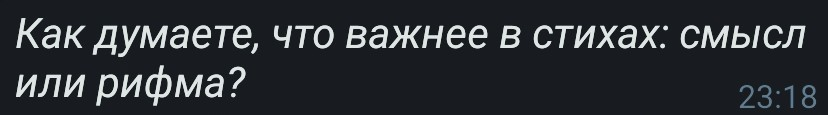

#### Я смыслоцентрична — это осознанный авторский выбор. Отвечу просто: смысл — тело, рифма — рубаха. Рубаха может быть красива, но если под ней пустота — выходить в люди не с чем. А красивое тело и без платья — искусство. Это очень житейское определение; если копнуть глубже, то конкуренция этих двух категорий кажется невозможной ввиду разных полей воздействия и зон ответственности.

#### В защиту рифмы хочу отметить, что это всё же в первую очередь эквивалентность, которая нацелена на человеческое восприятие, с другой стороны, нередко встречается избыточность (с целью разжевать всё читателю), и я категорически против неё. Так, слыша первую строку, мозг уже прогнозирует конец второй, и всё становится слишком предсказуемым. А поэзия — это всё-таки вызов, в какой-то степени и нейронаучный.

# **________**

# **Я не люблю поэтов, но они в этом не виноваты**

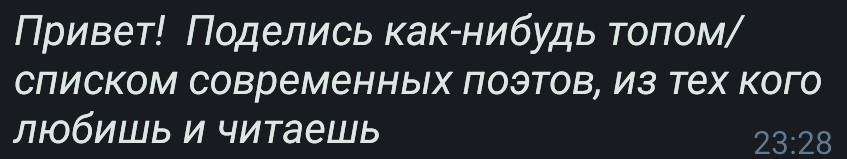

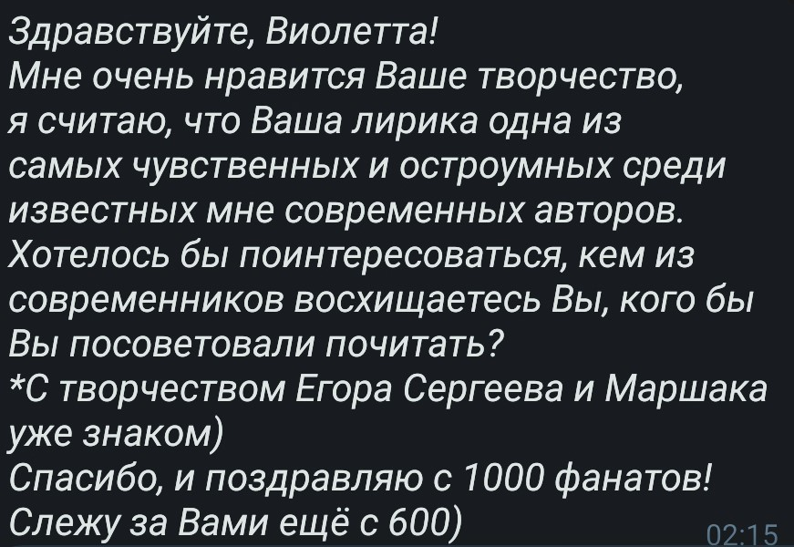

#### Виноваты их тексты, потому что я очень текстоцентрична. По этой же причине не завожу себе поэтических любимцев, иначе бы пришлось заводить слишком много любовников. Иногда достаточно всего одного текста, чтобы быть благодарным автору, некоторые же авторы пробивают смысловое поле и у тебя не остается шансов не читать их.

#### Читаю очень многих современников, сделаю как-нибудь подборку любимых/близких текстов. Но, чтобы совсем не оставлять Вас со своим снобством, покажу четыре имени (вообще их 5-ть, но 5-е уже упомянули), которые я сейчас читаю, не пропуская ни одного текста: Марта (мартовские стихи), Румяна (румяна пишет), Александра Пронина (большая и малая дурость), Стас ХП.

# **________**

# **Сейчас будет больная тема**

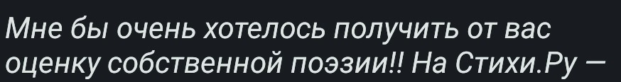

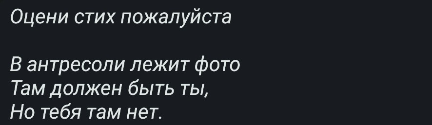

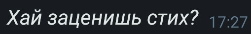

#### Зачастую наблюдаю, как автор просит другого автора оценить его труд. Меня это иногда парализует, потому что как только текст дописан и попал в другие руки — он живёт. Шанс выживаемости всегда разнится, но оценка его не увеличит и не уменьшит. Сама просьба кажется мне утопичной: тот, кого вы просите, никогда не будет читать с позиции автора — только с позиции читателя. А читатель может поделиться впечатлением, описать мысли или эмоции — но никак не оценить. Поэтому, при всей солидарности с этим иногда невыносимым желанием понять "кто такой мой текст и какова его вероятность выживаемости", я не нахожу это этичным.

# **________**

# **Поясни за красоту**

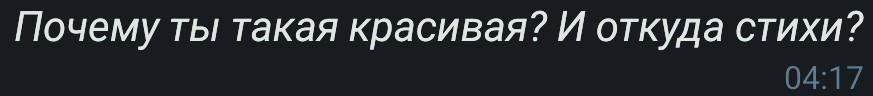

#### Потому что я — женщина, а женщины все красивы. К слову, я больше сконцентрирована на некрасоте, без которой красота невозможна. Красота есть разного уровня: одну надо считывать, другую приходится разгадывать: механически это похоже на уравнение с недостающей переменной, где некрасота как раз очень помогает понять что нужно найти.

#### А стихи появились с фиксированием мыслей на бумаге — я начала почти регулярно делать записи в личном дневнике и заигралась. И слово в качестве метода выражения оказалось в нужное время. (А, если это был вопрос о географии, то из Волгограда).

# **________**

# **Поясни за суку**

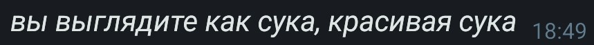

#### Слово "сука" в мире литературы вызывает у меня сильную эмоцию. Оно будто обмануло всех вокруг, сломало систему и радуется втихомолку. Это — отчасти о легитимности его значений, о семантической нагрузке, хотя современная поэзия не чурается слов разного эшелона.

#### И то, что "сука" всякий раз становится маленькой радостью шестиклассника, читающего большого гиганта литературы, вызывает у меня умиление. А в живом русском языке слово "сука", мне кажется, стало элитарным ругательством. Не всех можно назвать суками. Сука — это надо уметь кусаться.

#### В общем, мне очень нравится его обсцентизм: он эстетичен, надчеловечен, но легален, что само по себе является противоречием. "Сука" - это контрабанда, которую удалось пронести в большое поле культурных нарративов.

# **________**

# **Хочется просто поговорить о смерти**

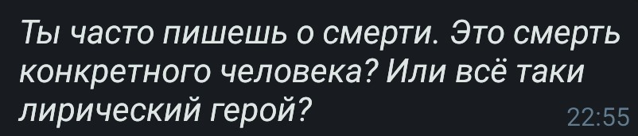

#### Вопрос широкий, но я попробую показать.

#### Это оба случая. Интенции написания у них разношёрстны, как и я с лирическим героем в соотношении со смертью. Лирический герой у меня находится со смертью на одном уровне: он не проживает смерть, а живёт с ней. В этом его суперсила.

#### Мне же смерть любопытна как факт. Я часто сталкиваюсь с ней — человеческой, нечеловеческой, чужой, родной. И у меня есть тяга к акселерации и доведению всего до конечной мысли: перед тем как что-то сделать, хочется понимать, как оно будет умирать (логично заканчиваться). Объяснить себе это пока что мало получается.

#### А смерть. Смерть — такая же данность. Мне даже видится, что она — одна из самых главных. Возможно, мы недооцениваем естественную смерть.

# **________**

# **ft.**

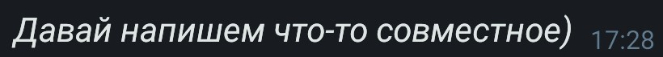

Я не против совместного написания стихов, как идеи, поскольку крайний случай такого примера — это допущение, где все люди мира напишут вместе стих. На данный момент это звучит иллюзорно, а с другой стороны уже существуют народные стихи и существуют очень твёрдо. Два автора — это самый начальный этап, все люди — крайняя степень, народные, наверное — адекватная середина. Это любопытный социально-культурный опыт. Для самой поэзии — это практика экспериментирования, которая в любом из исходов, как методика, что-то скажет. Но на практике, я достаточно противна и дотошна, как автор, к этому нужно быть готовым: совместный текст не по любви, а по сотрудничеству пишется кропотливо.

# **________**

# **Кем не стать, когда вырасту**

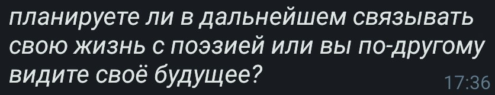

#### Я думаю так. Я не выбирала поэзию и не ставила крест на искусстве, это неизбежность и, если угодно, космическая детерминация — она и радостна и трагична. Я не знаю практически ничего об этом, кроме того как то, что я от этого никуда не убегу. А будущее строю по принципу гофмоновской множественности миров, где каждое я, как актор — это нечто разное (в моем случае аналитик может быть поэтом). Да и никогда не было представления о том, кем я хочу стать, зато я всегда знала кем стать не хочу.

# **________**

# **Секс: коротко и по делу**

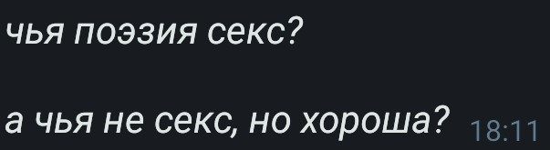

#### Ахаха, вся поэзия — секс. Смотря какое стихосложение Вы предпочитаете: классическую силлабо-тонику, свободные формы с элементами верлибра, белые стихи...

#### Без шуток, зачитываюсь Заболоцким.

# **________**

# **Зачем типологии Юнга, если есть Смешарики?**

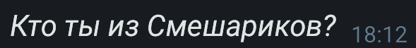

#### Смешариков я смотрела с самого маленького детства и до сих пор иногда могу. С возрастом я всякий раз меняла своего главного героя, сейчас же, я бы забрала у каждого персонажа что-то и создала своего смешарика. У Кроша — жизнерадостность и энергию, Ёжика — воспитанность и впечатлительность, Нюши — кокетство, Бараша — одиночество и отстранённость, Лосяша — склонность к авантюрам и исследовательских дух, Карыча — демонстративность и харизму, Совуньи — следование здоровому образу жизни и собирание трав, Копатыча — прямолинейность и трудолюбие , Пина — изобретательность.

#### Но, но, если читерить нельзя, то я выберу Биби. Во-первых, мы с ним ближе всего по родственности душ, во-вторых, как-то я искала чем заменить обращения "детка/ малыш", которые мне абсолютно не нравятся и нашла французское "bebe", от которого я в восторге, меня так, увы, называть не стали, и вообще любовь не удалась, да и какая любовь может быть после такого? Выбор в пользу красивого слова очевиден.

# **________**

# **Гадаем по книге Дж. Оруэлла "Дочь священника"**

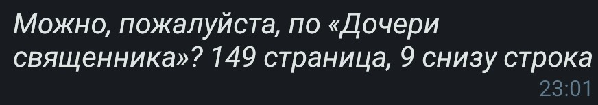

#### На этой строке одно полное предложение:

> Не жизнь, а мечта идиота.

#### Кто бы вы ни был, вы умеете целиться, хых.

# **________**

# **О вдохновении**

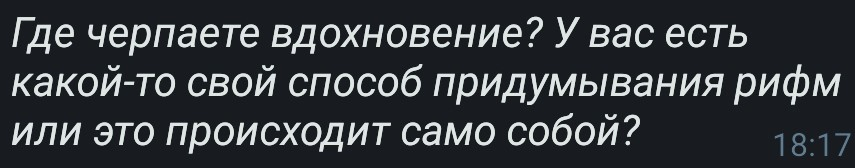

#### Вдохновение — люди, у меня это всегда люди. Неживое, предметы — это тоже всегда люди (солидарна в этом плане с объяснительными схемами Латура и Зиммеля и ряда последователей концепций, где вещи — это не материальное, а смысловое единство). Это к тому, что я не всегда думаю о человеке как человеке или о тумбе как тумбе, скорее о человеке как о тумбе.

#### Рифмы придумываются интуитивно и очень спонтанно, я думаю о мысли, которую хочу выразить и вокруг начинают бегать слова, по итогу нужное слово остается, другие — растворяются. Впрочем, иногда, я могу потерять рифму и строить структуру стиха на ритме и созвучии (это к возвращению размышлений о смыслоцентричности).

# **Ванильные дни недели**

#### Благодарю Вас за участие и интересные вопросы. Гневных сообщений было малое количество и очень много теплоты (я не стала вмещать сюда всё, иначе бы мы устали, хых), поэтому напоследок оставляю Вам вот такое точное и ёмкое послание. Пусть у весны все дни — ванильные дни недели❤

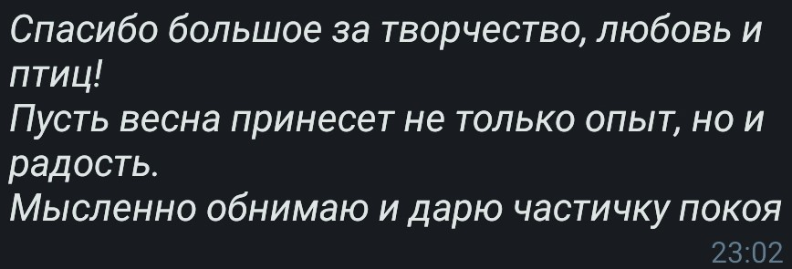

# **________Из любви, Ви.**